# Hash Function

hash function adalah fungsi yang menerima input (atau kunci) dengan ukuran sembarang dan mengubahnya menjadi nilai berukuran tetap, yang disebut nilai hash atau kode hash.

```
Misalnya, menggunakan metode modulo:
H(x) = x % 10
```

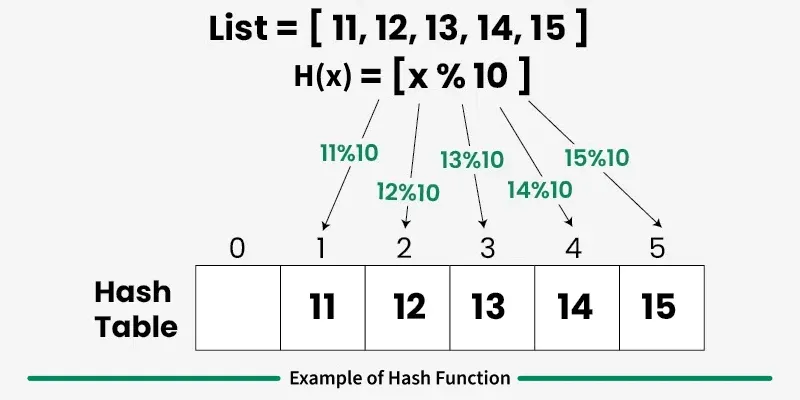

Fungsi ini mengubah angka besar apa pun menjadi nilai antara 0 dan 9, sehingga cocok untuk pengindeksan dalam tabel hash. Hashing memungkinkan penyimpanan yang efisien dan pengambilan data yang cepat.

### Contoh Hash Function

Berikut adalah contoh yang menunjukkan bagaimana kunci input dipetakan ke nilai hash untuk penyimpanan dan pengambilan yang efisien.

1. Gunakan dua digit terakhir dari nomor telepon sebagai nilai hash.

   hash function

   h(k) = k mod 100
- Ukuran tabel hash adalah 100, sehingga indeks yang valid berkisar dari 0 hingga 99.
- Dengan mengambil dua digit terakhir, output selalu berada dalam rentang ini.

> **Catatan** : Mengambil dua digit pertama bukanlah pilihan yang baik karena banyak nomor telepon memiliki digit awal yang sama, yang menyebabkan distribusi yang buruk dan lebih banyak tabrakan.
2. String Bahasa Inggris Huruf Kecil sebagai Tombol

Berikan nilai pada karakter (a = 1, b = 2, ..., z = 26), jumlahkan, dan ambil modulonya.

```
hash function:

h(s) = (jumlah nilai karakter) mod 100
```

Hal ini menyebabkan collisions (tabrakan).

## Sifat-Sifat Hash Function

Hash function yang baik harus memenuhi properti tertentu untuk memastikan penyimpanan, pengambilan, dan keamanan data yang efisien dan andal.

- Deterministik : Sebuah hash function harus secara konsisten menghasilkan output yang sama untuk input yang sama.
- Ukuran Output Tetap : Output dari hash function harus memiliki ukuran tetap, terlepas dari ukuran inputnya.
- Efisiensi : hash function harus mampu memproses input dengan cepat.
- Keseragaman : hash function harus mendistribusikan nilai hash secara seragam di seluruh ruang keluaran untuk menghindari pengelompokan.
- Ketahanan terhadap serangan pre-image : Secara komputasi, seharusnya tidak mungkin untuk membalikkan hash function, yaitu, untuk menemukan input asli berdasarkan nilai hash yang diberikan.
- Ketahanan terhadap benturan (Collision Resistance ): Seharusnya sulit untuk menemukan dua input berbeda yang menghasilkan nilai hash yang sama.
- Efek Longsoran : Perubahan kecil pada input akan menghasilkan nilai hash yang berbeda secara signifikan.

## Aplikasi Hash Function

Hash Function banyak digunakan di berbagai bidang karena efisiensi dan fleksibilitasnya:

- Tabel Hash : Penggunaan Hash Function yang paling umum dalam DSA adalah pada tabel hash, yang menyediakan cara efisien untuk menyimpan dan mengambil data.
- Integritas Data : Hash Function digunakan untuk memastikan integritas data dengan menghasilkan checksum.
- Kriptografi : Dalam aplikasi kriptografi, Hash Function digunakan untuk membuat algoritma hash yang aman seperti SHA-256.
- Struktur Data : Hash Function digunakan dalam berbagai struktur data seperti filter Bloom dan himpunan hash.

## Jenis-jenis Hash Function

Berbagai teknik hashing digunakan tergantung pada kebutuhan aplikasi. Berikut adalah jenis-jenis yang umum digunakan:

### 1. Metode Pembagian

Metode pembagian menghitung nilai hash sebagai sisa ketika kunci dibagi dengan m, di mana m biasanya dipilih sebagai bilangan prima.

```
h ( k )= k mod m
Di mana k adalah kunci dan m biasanya dipilih sebagai bilangan prima.
```

Keuntungan :

- Mudah diimplementasikan.
- Berfungsi dengan baik jika m adalah bilangan prima.

Kekurangan :

- Distribusi yang buruk jika m tidak dipilih dengan bijak.

### 2. Metode Perkalian

Dalam metode ini, kunci dikalikan dengan konstanta A (di mana 0 < A < 1). Bagian pecahan dari hasilnya kemudian dikalikan dengan m untuk mendapatkan nilai hash

```
h ( k )=⌊ m * (( k * A) mod 1)⌋
Di mana ⌊ ⌋ menunjukkan fungsi lantai..
```

Berbeda dengan metode pembagian, teknik ini kurang bergantung pada nilai m, sehingga lebih fleksibel dalam praktiknya.

Keuntungan :

- Memberikan distribusi yang lebih baik dalam banyak kasus.
- Kurang sensitif terhadap ukuran meja.

Kekurangan :

- Perhitungannya sedikit lebih kompleks.

### 3. Metode Titik Tengah Persegi

Metode ini melibatkan pengkuadratan kunci dan mengekstrak bagian tengah dari hasilnya untuk menghasilkan nilai hash.

```
Langkah-langkah :
1. Persegikan kuncinya.
2. Ambil angka tengah dari nilai kuadrat tersebut.
```

Mengkuadratkan kunci membantu menyebarkan angka-angka, yang seringkali menghasilkan distribusi nilai hash yang lebih seragam.

Keuntungan :

- Menghasilkan distribusi nilai hash yang baik.

Kekurangan :

- Mungkin memerlukan upaya komputasi yang lebih besar.

### 4. Metode Melipat

Dalam metode pelipatan (folding), kunci dibagi menjadi beberapa bagian yang lebih kecil, dan bagian-bagian ini digabungkan (biasanya dengan penjumlahan) untuk menghasilkan nilai hash.

[output not shown]

Keuntungan :

- Sederhana dan mudah diterapkan.
- Cocok untuk tombol berukuran besar.
- Fleksibel dalam strategi partisi.

Kekurangan :

- Kualitas bergantung pada bagaimana kunci tersebut dibagi.
- Nilai mungkin tidak terdistribusi secara seragam jika komponennya serupa.

### 5. Hash Function Kriptografi

Hash Function ini dirancang untuk keamanan, bukan kecepatan. Fungsi ini digunakan dalam aplikasi di mana perlindungan data sangat penting.

```
Contohnya termasuk SHA-256 dan SHA-3, yang banyak digunakan dalam aplikasi keamanan seperti hashing kata sandi dan blockchain.
```

Mereka memastikan sifat-sifat yang kuat seperti ketahanan terhadap serangan pre-image, ketahanan terhadap serangan second pre-image, dan ketahanan terhadap serangan collision, sehingga cocok untuk sistem yang aman.

Keuntungan :

- Sangat aman dan andal.

Kekurangan :

- Lebih lambat dibandingkan dengan Hash Function non-kriptografis.

### 6. Hashing Universal

Hashing universal menggunakan sekumpulan Hash Function dan memilih salah satunya secara acak saat runtime. Tujuannya adalah untuk meminimalkan probabilitas tabrakan terlepas dari distribusi input.

```
h ( k )=(( a * k + b ) mod p ) mod m
Di mana a dan b adalah konstanta yang dipilih secara acak, p adalah bilangan prima yang lebih besar dari m , dan k adalah kuncinya.
```

Dengan memperkenalkan unsur acak, metode ini mencegah penyerang atau input terburuk menurunkan kinerja.

Keuntungan :

- Mengurangi kemungkinan tabrakan.
- Lebih tangguh terhadap input yang bersifat antagonis.

Kekurangan :

- Membutuhkan lebih banyak daya komputasi dan penyimpanan.

### 7. Hashing Sempurna

Perfect hashing adalah teknik yang digunakan untuk membangun Hash Function untuk sekumpulan kunci tetap, memastikan bahwa setiap kunci dipetakan ke indeks unik tanpa adanya benturan (collision).

Perfect hashing umumnya diklasifikasikan menjadi dua jenis utama:

- Minimal Perfect Hashing: Memastikan bahwa rentang Hash Function sama dengan jumlah kunci.
- Hashing Sempurna Non-minimal: Rentangnya mungkin lebih besar daripada jumlah kunci.

Keuntungan :

- Menghilangkan tabrakan sepenuhnya.

Kekurangan :

- Sulit untuk dibangun.
- Tidak cocok untuk data dinamis.